# final_project

Transition Probabilities for TRAINING Set

|  | to 0 | to 1 | to 2 | to 3 | to 4 |
| --- | --- | --- | --- | --- | --- |
| from 0 | 0.809843 | 0.138702 | 0.000000 | 0.051454 | 0.000000 |
| from 1 | 0.290541 | 0.351351 | 0.020270 | 0.324324 | 0.013514 |
| from 2 | 0.000000 | 0.333333 | 0.466667 | 0.133333 | 0.066667 |
| from 3 | 0.500000 | 0.333333 | 0.011905 | 0.130952 | 0.023810 |
| from 4 | 0.000000 | 0.200000 | 0.800000 | 0.000000 | 0.000000 |

Counts of Transitions for TRAINING Set

|  | to 0 | to 1 | to 2 | to 3 | to 4 |
| --- | --- | --- | --- | --- | --- |
| from 0 | 362 | 62 | 0 | 23 | 0 |
| from 1 | 43 | 52 | 3 | 48 | 2 |
| from 2 | 0 | 5 | 7 | 2 | 1 |
| from 3 | 42 | 28 | 1 | 11 | 2 |
| from 4 | 0 | 1 | 4 | 0 | 0 |

Transition Probabilities for TEST Set

|  | to 0 | to 1 | to 2 | to 3 | to 4 |
| --- | --- | --- | --- | --- | --- |
| from 0 | 0.721893 | 0.195266 | 0.000000 | 0.076923 | 0.005917 |
| from 1 | 0.285714 | 0.300000 | 0.014286 | 0.385714 | 0.014286 |
| from 2 | 0.000000 | 0.000000 | 0.333333 | 0.333333 | 0.333333 |
| from 3 | 0.481481 | 0.296296 | 0.000000 | 0.222222 | 0.000000 |
| from 4 | 0.000000 | 0.000000 | 0.333333 | 0.333333 | 0.333333 |

Counts of Transitions for TEST Set

|  | to 0 | to 1 | to 2 | to 3 | to 4 |
| --- | --- | --- | --- | --- | --- |
| from 0 | 122 | 33 | 0 | 13 | 1 |
| from 1 | 20 | 21 | 1 | 27 | 1 |
| from 2 | 0 | 0 | 1 | 1 | 1 |
| from 3 | 26 | 16 | 0 | 12 | 0 |
| from 4 | 0 | 0 | 1 | 1 | 1 |

```
Total transitions out of regime 0 (train):  447
Total transitions out of regime 1 (train):  148
Total transitions out of regime 0 (test):  169
Total transitions out of regime 1 (test):  70

One-step Markov 1-day accuracy on TEST: 0.591973
```

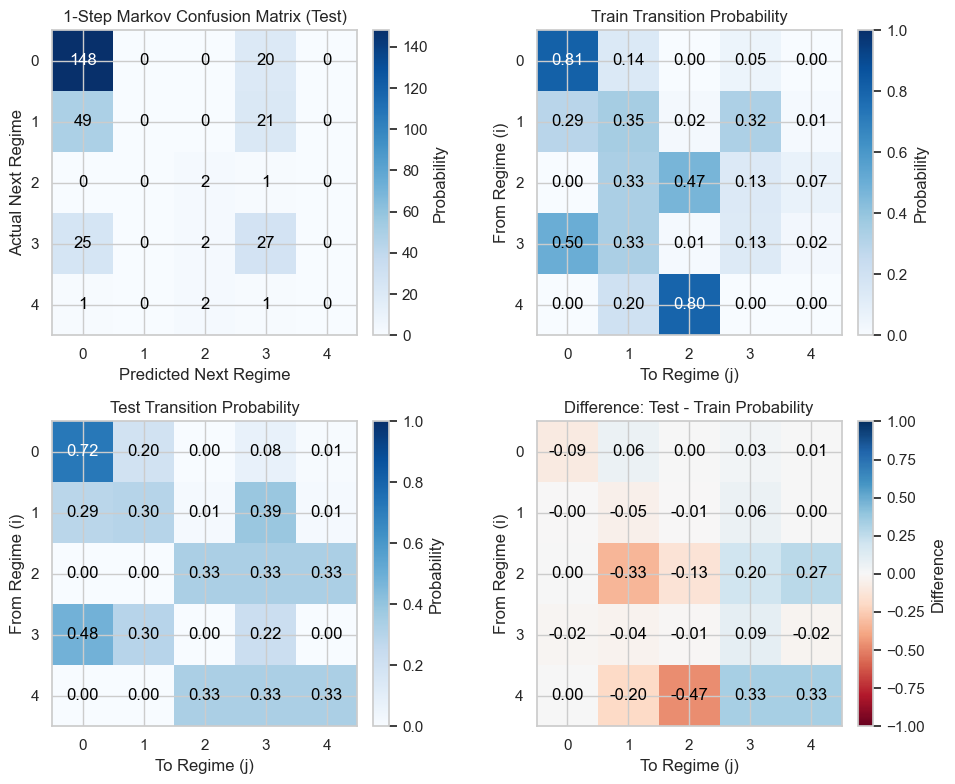

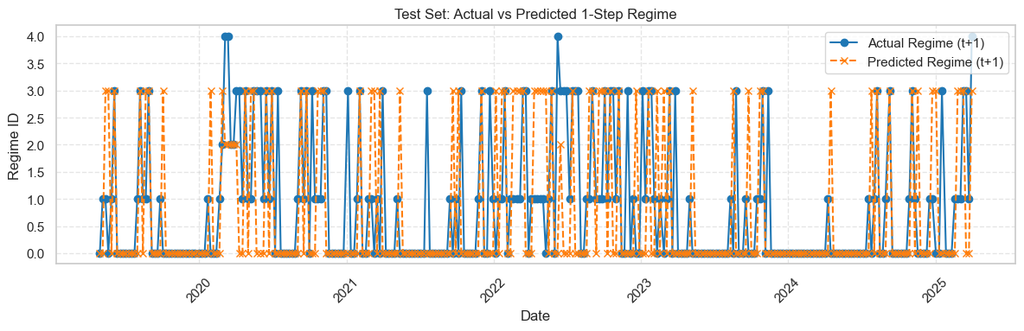

```python
reset_session()

n_total = len(df_simple)
n_train = len(X_train_eh)
n_test  = len(X_test_eh)

# Extract the sequence of “current” regimes from distribution_df
all_regimes = df_simple['regime_best'].to_numpy()

# regimes corresponding to the training window (first n_train rows)
regimes_train = all_regimes[:n_train]

# regimes corresponding to the test window (next n_test rows)
regimes_test  = all_regimes[n_train : n_train + n_test]

# Ground‐truth “future” regime_target at t+21 for test
y_true = y_test_eh

# Number of distinct regimes (k_best from k-means)
k_best = df_simple['regime_best'].nunique()
states = np.arange(k_best)

def estimate_transitions(labels, k):
    counts = np.zeros((k, k), dtype=int)
    for t in range(len(labels) - 1):
        i = labels[t]
        j = labels[t + 1]
        counts[i, j] += 1

    row_sums = counts.sum(axis=1)
    probs = np.zeros_like(counts, dtype=float)
    for i in range(k):
        if row_sums[i] > 0:
            probs[i, :] = counts[i, :] / row_sums[i]
        else:
            probs[i, :] = np.nan

    return counts, probs

counts_train, P_train = estimate_transitions(regimes_train, k_best)

idx = [f"from {i}" for i in range(k_best)]
cols = [f"to {j}"   for j in range(k_best)]

df_counts_train = pd.DataFrame(counts_train, index=idx, columns=cols)
df_P_train      = pd.DataFrame(P_train,      index=idx, columns=cols)

counts_test, P_test = estimate_transitions(regimes_test, k_best)

df_counts_test = pd.DataFrame(counts_test, index=idx, columns=cols)
df_P_test      = pd.DataFrame(P_test,      index=idx, columns=cols)

display(Markdown("#### Transition Probabilities for TRAINING Set"))
display(df_P_train)

display(Markdown("#### Counts of Transitions for TRAINING Set"))
display(df_counts_train)

display(Markdown("#### Transition Probabilities for TEST Set"))
display(df_P_test)

display(Markdown("#### Counts of Transitions for TEST Set"))
display(df_counts_test)

print(f"Total transitions out of regime 0 (train): ", df_counts_train.iloc[0].sum())
print(f"Total transitions out of regime 1 (train): ", df_counts_train.iloc[1].sum())
print(f"Total transitions out of regime 0 (test): ", df_counts_test.iloc[0].sum())
print(f"Total transitions out of regime 1 (test): ", df_counts_test.iloc[1].sum())

regime_test_next    = regimes_test[1:]       # actual regime at t+1 in test
regime_test_current = regimes_test[:-1]      # regime at t

y1_true = regime_test_next
y1_pred = np.array([np.nan if np.isnan(P_test[s]).all() else np.nanargmax(P_test[s]) for s in regime_test_current])

valid_mask = ~np.isnan(y1_pred)
y1_true = y1_true[valid_mask].astype(int)
y1_pred = y1_pred[valid_mask].astype(int)
#print("Prediction of the test data:", y1_pred)

acc1 = accuracy_score(y1_true, y1_pred)
print(f"\nOne-step Markov 1-day accuracy on TEST: {acc1:.6f}")

cm1 = confusion_matrix(y1_true, y1_pred, labels=states)

# Calculate difference matrix for the bottom-right subplot
diff = P_test - P_train

# Create 2x2 subplots
fig, axes = plt.subplots(2, 2, figsize=(10, 8))

# Subplot (0,0): force a square‐cell heatmap
ax_cm = axes[0, 0]
im_cm = ax_cm.imshow(cm1, aspect='equal', cmap='Blues')
ax_cm.set_title('1-Step Markov Confusion Matrix (Test)')
ax_cm.set_xlabel('Predicted Next Regime')
ax_cm.set_ylabel('Actual Next Regime')
ax_cm.set_xticks(states)
ax_cm.set_yticks(states)
for i in states:
    for j in states:
        ax_cm.text(j, i, cm1[i, j], ha='center', va='center',
                   color=('white' if cm1[i, j] > cm1.max()/2 else 'black'))
cbar_cm = fig.colorbar(im_cm, ax=ax_cm, fraction=0.046, pad=0.04)
cbar_cm.set_label('Probability')

# Subplot (0,1): also force square‐cell
ax_train = axes[0, 1]
im_train = ax_train.imshow(P_train, aspect='equal', cmap='Blues', vmin=0, vmax=1)
ax_train.set_title('Train Transition Probability')
ax_train.set_xlabel('To Regime (j)')
ax_train.set_ylabel('From Regime (i)')
ax_train.set_xticks(states)
ax_train.set_yticks(states)
for i in states:
    for j in states:
        val = P_train[i, j]
        if not np.isnan(val):
            ax_train.text(j, i, f"{val:.2f}", ha='center', va='center',
                          color=('white' if val > 0.5 else 'black'))
cbar_train = fig.colorbar(im_train, ax=ax_train, fraction=0.046, pad=0.04)
cbar_train.set_label('Probability')

# ---- Subplot (1,0): Test Transition Probability Heatmap ----
ax_test = axes[1, 0]
im_test = ax_test.imshow(P_test, cmap='Blues', vmin=0, vmax=1)
ax_test.set_title('Test Transition Probability')
ax_test.set_xlabel('To Regime (j)')
ax_test.set_ylabel('From Regime (i)')
ax_test.set_xticks(states)
ax_test.set_yticks(states)
for i in states:
    for j in states:
        val = P_test[i, j]
        if not np.isnan(val):
            color = 'white' if val > 0.5 else 'black'
            ax_test.text(j, i, f"{val:.2f}", ha='center', va='center', color=color)
cbar_test = fig.colorbar(im_test, ax=ax_test, fraction=0.046, pad=0.04)
cbar_test.set_label('Probability')

# ---- Subplot (1,1): Difference Heatmap (Test - Train) ----
ax_diff = axes[1, 1]
im_diff = ax_diff.imshow(diff, cmap='RdBu', vmin=-1, vmax=1)
ax_diff.set_title('Difference: Test - Train Probability')
ax_diff.set_xlabel('To Regime (j)')
ax_diff.set_ylabel('From Regime (i)')
ax_diff.set_xticks(states)
ax_diff.set_yticks(states)
for i in states:
    for j in states:
        val = diff[i, j]
        if not np.isnan(val):
            color = 'white' if abs(val) > 0.5 else 'black'
            ax_diff.text(j, i, f"{val:.2f}", ha='center', va='center', color=color)
cbar_diff = fig.colorbar(im_diff, ax=ax_diff, fraction=0.046, pad=0.04)
cbar_diff.set_label('Difference')

plt.tight_layout()
plt.show()


dates_test = df_simple['start_date'].iloc[n_train+1 : n_train+1+len(y1_true)].to_numpy()
regimes_actual_ts = y1_true
regimes_pred_ts = y1_pred

fig3, ax3 = plt.subplots(figsize=(12, 4))
ax3.plot(dates_test, regimes_actual_ts, label='Actual Regime (t+1)', marker='o', linestyle='-', color='#1f77b4')
ax3.plot(dates_test, regimes_pred_ts, label='Predicted Regime (t+1)', marker='x', linestyle='--', color='#ff7f0e')
ax3.set_title('Test Set: Actual vs Predicted 1-Step Regime')
ax3.set_xlabel('Date')
ax3.set_ylabel('Regime ID')
ax3.xaxis.set_major_locator(YearLocator())
ax3.xaxis.set_major_formatter(DateFormatter('%Y'))
ax3.legend()
ax3.grid(True, linestyle='--', alpha=0.5)
plt.xticks(rotation=45)

plt.tight_layout()

# Display all figures
plt.show()
```

**Softmax Regression with Neural Network**

Description:

The model is a **softmax regression neural network implemented using Keras**, designed for multi-class classification of market regimes. It consists of an input layer matching the number of standardized financial features, followed by a dense hidden layer with 64 neurons and ReLU activation to capture non-linear patterns.

We used a dropout layer with a rate of 0.3 for regularization to prevent overfitting. The output layer uses a softmax activation function to produce class probabilities across multiple regime labels. The model is compiled with sparse categorical cross-entropy loss and optimized using the Adam optimizer with a learning rate of 0.001. **To account for class imbalance,** class weights are computed and applied during training. An early stopping mechanism is used to monitor validation loss and restore the best model weights, ensuring stable and efficient convergence.

[output not shown]

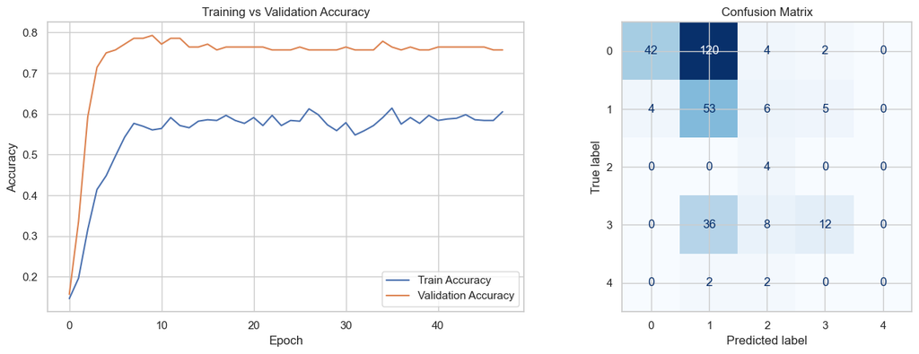

```
Classification Report:
              precision    recall  f1-score   support

           0      0.913     0.250     0.393       168
           1      0.251     0.779     0.380        68
           2      0.167     1.000     0.286         4
           3      0.632     0.214     0.320        56
           4      0.000     0.000     0.000         4

    accuracy                          0.370       300
   macro avg      0.392     0.449     0.276       300
weighted avg      0.688     0.370     0.369       300
```

```python
reset_session()

num_classes = len(np.unique(y_train))
class_weights = class_weight.compute_class_weight(
    class_weight='balanced',
    classes=np.unique(y_train),
    y=y_train)
class_weight_dict = dict(enumerate(class_weights))
print("Class Weights:", class_weight_dict)

keras.backend.clear_session()
model = keras.Sequential([
    layers.Input(shape=(X_train_scaled.shape[1],)),
    layers.Dense(64, activation='relu'),
    layers.Dropout(0.3),
    layers.Dense(num_classes, activation='softmax')])

model.compile(loss='sparse_categorical_crossentropy', optimizer=keras.optimizers.Adam(learning_rate=0.001), metrics=['accuracy'])

early_stop = EarlyStopping(monitor='val_loss', patience=5, restore_best_weights=True)
history = model.fit(X_train_scaled, y_train, validation_split=0.2, epochs=50, class_weight=class_weight_dict, callbacks=[early_stop], verbose=1)
test_loss, test_acc = model.evaluate(X_test_scaled, y_test, verbose=0)
print(f"Test Accuracy: {test_acc:.3f}")

# Generate predictions for the confusion matrix
y_pred_probs = model.predict(X_test_scaled)
y_pred_classes = np.argmax(y_pred_probs, axis=1)

# Compute confusion matrix
cm = confusion_matrix(y_test, y_pred_classes)
# Create 1x2 subplots
fig, (ax1, ax2) = plt.subplots(1, 2, figsize=(14, 5))

# ---- Subplot 1: Training vs Validation Accuracy ----
ax1.plot(history.history['accuracy'], label='Train Accuracy')
ax1.plot(history.history['val_accuracy'], label='Validation Accuracy')
ax1.set_title("Training vs Validation Accuracy")
ax1.set_xlabel("Epoch")
ax1.set_ylabel("Accuracy")
ax1.legend()
ax1.grid(True)

# ---- Subplot 2: Confusion Matrix ----
disp = ConfusionMatrixDisplay(confusion_matrix=cm)
disp.plot(cmap="Blues", ax=ax2, colorbar=False)
ax2.set_title("Confusion Matrix")

plt.tight_layout()
plt.show()
print("Classification Report:")
print(classification_report(y_test, y_pred_classes, digits=3, zero_division=0))
```

**Gradient Boosting**

Desciption:

Gradient Boosting is a powerful ensemble method that **builds a strong classifier by combining many shallow decision trees,** where each tree corrects the errors of the previous one. It is well-suited for financial data because it can capture complex, nonlinear relationships while controlling for overfitting through parameters like learning rate, tree depth, and subsampling.

In our project, we used GradientBoostingClassifier within a pipeline that includes standard scaling and time-series cross-validation (TimeSeriesSplit) to respect the **chronological nature of financial data**. A grid search was used to tune hyperparameters and select the best-performing model.

We chose Gradient Boosting because it handles limited features well, provides good predictive performance, and offers some interpretability through feature importance. It serves as both a strong predictive model and a benchmark against which more complex models like neural networks or XGBoost can be compared.

```
Fitting 5 folds for each of 16 candidates, totalling 80 fits
Best GB parameters:  {'gb__learning_rate': 0.05, 'gb__max_depth': 3, 'gb__n_estimators': 200, 'gb__subsample': 0.8}
Best CV accuracy:  0.6137931034482759
Train Accuracy: 0.98
Test Accuracy: 0.5533333333333333
Test F1 (Macro): 0.2951523400457411

Classification report on test set:

              precision    recall  f1-score   support

           0       0.84      0.66      0.74       168
           1       0.31      0.59      0.41        68
           2       0.00      0.00      0.00         4
           3       0.43      0.27      0.33        56
           4       0.00      0.00      0.00         4

    accuracy                           0.55       300
   macro avg       0.32      0.30      0.30       300
weighted avg       0.62      0.55      0.57       300
```

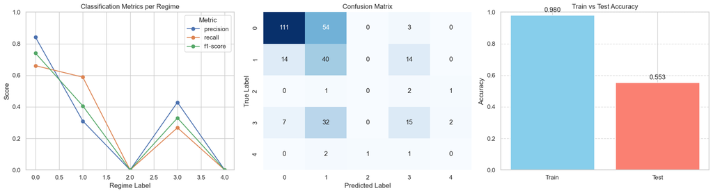

```python
pipe_gb = Pipeline([
    ("scaler", StandardScaler()),
    ("gb", GradientBoostingClassifier(random_state=42))
])

param_grid_gb = {
    'gb__n_estimators': [100, 200],
    'gb__learning_rate': [0.1, 0.05],
    'gb__max_depth': [3, 5],
    'gb__subsample': [0.8, 1.0]
}

tscv = TimeSeriesSplit(n_splits=5)

grid_gb = GridSearchCV(
    pipe_gb,
    param_grid=param_grid_gb,
    cv=tscv,
    scoring='accuracy',
    n_jobs=-1,
    verbose=1,
    refit=True
)

grid_gb.fit(X_train_lm, y_train_lm)

print("Best GB parameters: ", grid_gb.best_params_)
print("Best CV accuracy: ", grid_gb.best_score_)

best_gb = grid_gb.best_estimator_
y_pred_lm = best_gb.predict(X_test_lm)

test_acc_lm = accuracy_score(y_test_lm, y_pred_lm)
test_f1_lm = f1_score(y_test_lm, y_pred_lm, average="macro")
train_acc_lm = accuracy_score(y_train_lm, best_gb.predict(X_train_lm))

print("Train Accuracy:", train_acc_lm)
print("Test Accuracy:", test_acc_lm)
print("Test F1 (Macro):", test_f1_lm)
print("\nClassification report on test set:\n")
print(classification_report(y_test_lm, y_pred_lm, zero_division=0))

report_dict_gb = classification_report(y_test_lm, y_pred_lm, output_dict=True, zero_division=0)
df_report_gb = pd.DataFrame(report_dict_gb).T
regime_metrics_gb = df_report_gb[df_report_gb.index.str.isnumeric()].copy()
regime_metrics_gb.index = regime_metrics_gb.index.astype(int)
regime_metrics_gb.sort_index(inplace=True)

cm_gb = confusion_matrix(y_test_lm, y_pred_lm)
fig, axs = plt.subplots(1, 3, figsize=(18, 5))

regime_metrics_gb[['precision', 'recall', 'f1-score']].plot(ax=axs[0], marker='o')
axs[0].set_title("Classification Metrics per Regime")
axs[0].set_xlabel("Regime Label")
axs[0].set_ylabel("Score")
axs[0].set_ylim(0, 1)
axs[0].legend(title="Metric")
axs[0].grid(True)

sns.heatmap(cm_gb, annot=True, fmt='d', cmap='Blues', cbar=False, ax=axs[1])
axs[1].set_title("Confusion Matrix")
axs[1].set_xlabel("Predicted Label")
axs[1].set_ylabel("True Label")

axs[2].bar(['Train', 'Test'], [train_acc_lm, test_acc_lm], color=['skyblue', 'salmon'])
axs[2].set_ylim(0, 1)
axs[2].set_title("Train vs Test Accuracy")
axs[2].set_ylabel("Accuracy")
for i, v in enumerate([train_acc_lm, test_acc_lm]):
    axs[2].text(i, v + 0.02, f"{v:.3f}", ha='center')
axs[2].grid(axis='y', linestyle='--', alpha=0.7)

plt.tight_layout()
plt.show()
```

**Random Forest**

Desciption:

We include Random Forest as one of the classification models due to its robustness to overfitting, ability to handle nonlinear relationships, and effectiveness in high-dimensional settings. Its ensemble nature allows it to **capture complex interactions between features** like rolling mean and standard deviation, making it well-suited for predicting market regime transitions based on historical volatility and return patterns.

```
Fitting 3 folds for each of 24 candidates, totalling 72 fits
Best Random Forest params (rx): {'rf__criterion': 'gini', 'rf__max_depth': 5, 'rf__min_samples_split': 5, 'rf__n_estimators': 100}
Best CV accuracy (rx): 0.6843537165425578
Test accuracy (rx): 0.63

Classification report (rx):
               precision    recall  f1-score   support

           0       0.73      0.89      0.80       168
           1       0.32      0.18      0.23        68
           2       0.50      0.25      0.33         4
           3       0.48      0.46      0.47        56
           4       0.00      0.00      0.00         4

    accuracy                           0.63       300
   macro avg       0.41      0.36      0.37       300
weighted avg       0.58      0.63      0.59       300
```

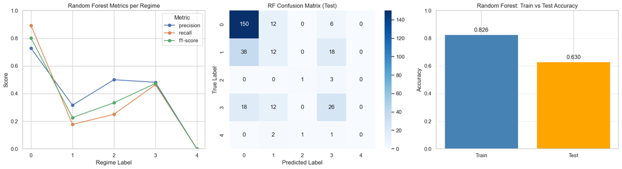

```python
reset_session()

pipe_rx = Pipeline([
    ('scaler', StandardScaler()),
    ('rf', RandomForestClassifier(random_state=42))])

param_grid_rx = {
    'rf__n_estimators': [100, 200],
    'rf__max_depth': [None, 5, 10],
    'rf__min_samples_split': [2, 5],
    'rf__criterion': ['gini', 'entropy']
}

grid_rx = GridSearchCV(
    estimator=pipe_rx,
    param_grid=param_grid_rx,
    cv=3,
    scoring='accuracy',
    verbose=1,
    n_jobs=-1,
    refit=True
)

# Fit grid search
grid_rx.fit(X_train_rx, y_train_rx)

# Best model
print("Best Random Forest params (rx):", grid_rx.best_params_)
print("Best CV accuracy (rx):", grid_rx.best_score_)

# Test set evaluation
best_rf_rx = grid_rx.best_estimator_
y_pred_rx = best_rf_rx.predict(X_test_rx)

print("Test accuracy (rx):", accuracy_score(y_test_rx, y_pred_rx))
print("\nClassification report (rx):\n", classification_report(y_test_rx, y_pred_rx, zero_division=0))
report_dict_rf = classification_report(y_test_rx, y_pred_rx, output_dict=True, zero_division=0)

# Convert to DataFrame
df_report_rf = pd.DataFrame(report_dict_rf).T

# Keep only numeric regime labels (e.g., "0", "1", "2", ...)
regime_metrics_rf = df_report_rf[df_report_rf.index.str.isnumeric()].copy()
regime_metrics_rf.index = regime_metrics_rf.index.astype(int)
regime_metrics_rf.sort_index(inplace=True)
cm = confusion_matrix(y_test_rx, y_pred_rx)
train_acc = accuracy_score(y_train_rx, best_rf_rx.predict(X_train_rx))
test_acc  = accuracy_score(y_test_rx,  best_rf_rx.predict(X_test_rx))

fig, axs = plt.subplots(1, 3, figsize=(18, 5))

regime_metrics_rf[['precision', 'recall', 'f1-score']].plot(ax=axs[0], marker='o')
axs[0].set_title("Random Forest Metrics per Regime")
axs[0].set_xlabel("Regime Label")
axs[0].set_ylabel("Score")
axs[0].set_ylim(0, 1)
axs[0].legend(title="Metric")
axs[0].grid(True)
axs[0].set_xticks(regime_metrics_rf.index)

sns.heatmap(cm, annot=True, fmt='d', cmap='Blues',
            xticklabels=best_rf_rx.named_steps['rf'].classes_,
            yticklabels=best_rf_rx.named_steps['rf'].classes_,
            ax=axs[1])
axs[1].set_xlabel('Predicted Label')
axs[1].set_ylabel('True Label')
axs[1].set_title('RF Confusion Matrix (Test)')

axs[2].bar(['Train', 'Test'], [train_acc, test_acc], color=['steelblue', 'orange'])
axs[2].set_ylim(0, 1)
axs[2].set_ylabel('Accuracy')
axs[2].set_title('Random Forest: Train vs Test Accuracy')
for i, v in enumerate([train_acc, test_acc]):
    axs[2].text(i, v + 0.02, f"{v:.3f}", ha='center')
axs[2].grid(axis='y', linestyle='--', linewidth=0.5)

plt.tight_layout()
plt.show()
```

**Support Vector Machine**